« Retour au Portfolio

# Exos1 Linéaires

### Exercice 1 - définir les types de problèmes

Notez, pour chaque cas ci-dessous, si vous utiliseriez une approche **statistique classique** ou une approche de **prédiction ML** pour résoudre le problème.

1. Une entreprise vous contacte et souhaite mener une campagne de marketing direct. L'objectif est d'identifier les individus qui répondront positivement à un mailing, sur la base d'observations de variables démographiques mesurées sur chaque individu. Ils enverront ensuite uniquement des courriers à ceux qui, selon eux, répondront positivement au courrier afin d'avoir un impact maximum pour un coût minimum.

Réponse : Prédiction individuelle (réponse au mailing) Prédiction ML

On cherche à prédire un comportement futur (réponse positive) à partir de variables démographiques. C’est typiquement un problème de classification supervisée.

2. Vous avez été contacté par Nicolas Cage. Il a de nombreuses offres de rôles dans de nouveaux films à venir mais ne peut pas toutes les accepter. Il souhaite utiliser des données historiques pour déterminer lesquels des films proposés sont susceptibles de connaître le plus grand succès. Il définit le succès comme la plus grande somme d’argent qu’un film rapporte. Il explique qu'il veut savoir quels facteurs, c'est-à-dire le nombre d'actrices primées, le budget, la durée du film, etc., sont les plus importants pour déterminer le succès d'un film.

Réponse : Analyse des facteurs influents + prédiction du succès Statistique classique + Prédiction ML

L’analyse des facteurs importants (corrélations, régressions) relève de la statistique. Mais prédire le succès futur d’un film (valeur numérique) est un problème de régression supervisée en ML.

3. Une association caritative internationale « Water for All » vous a contacté. Ils ont collecté des données sur l'utilisation, l'état actuel (fonctionne/ne fonctionne pas) et l'entretien des pompes à eau des communautés rurales dans plusieurs pays d'Afrique. Ils souhaitent savoir s'il est possible d'utiliser des modèles mathématiques pour comprendre quand se produira une future panne de chaque pompe à eau. Cela leur permettra d'envoyer leurs équipes à l'avance pour assurer une maintenance de protection afin d'éviter la panne de la pompe.

Réponse : Anticipation de pannes Prédiction ML

Il s’agit de prédire un événement futur (panne) à partir de données historiques. C’est un problème de classification ou de séries temporelles selon les données disponibles.

4. Vous venez d'être embauché par la police de Grenoble en tant que premier data scientist. Ils sont ravis de votre arrivée car un consultant en gestion très coûteux leur a dit que la « science des données » est l'avenir du maintien de l'ordre. Ils ont rassemblé toutes les informations dont ils disposaient sur les dates, les heures, la situation géographique et les rapports manuscrits sur les crimes historiques commis à Grenoble au cours de la dernière décennie. Ils attendent que vous leur disiez où aura lieu le prochain crime afin qu'ils puissent envoyer leurs agents à l'avance pour attraper les méchants avant que le crime ne se produise !

Réponse : Localisation et anticipation d’événements Prédiction ML

On cherche à prédire un événement spatio-temporel. Cela relève du ML, avec des modèles de séries temporelles, clustering spatial ou réseaux neuronaux.

5. *The Irresistable Chocolate Company* a commencé à tester de nouvelles recettes de chocolat. Ils ont embauché Sean Bean comme nouveau responsable de la recherche. Avec son insistance, leur modèle de consommation est désormais de rendre le chocolat si irrésistible que les clients n'ont d'autre choix que de le finir le plus tôt possible, et doivent ensuite en acheter davantage... augmentant ainsi les ventes. Leur nouvelle recette contient un *ingrédient secret*, qui n'est pas divulgué. On ne sait pas si la nouvelle recette satisfera aux normes légales, mais quoi qu’il en soit, l’équipe de recherche a commencé les tests auprès des consommateurs. Ils ont créé des barres de chocolat avec différentes proportions de cet ingrédient et ont mesuré le temps nécessaire aux clients pour consommer la barre entière. M. Bean aimerait en savoir plus sur la façon dont la proportion de l'ingrédient secret ajouté affecte le temps nécessaire à la consommation de la barre. Cela permettra à son équipe de recherche de perfectionner la nouvelle recette.

Réponse : Influence d’une variable sur une mesure Statistique classique

On cherche à comprendre l’effet d’une variable (proportion d’ingrédient) sur une autre (temps de consommation). Une régression linéaire classique suffit ici, sauf si le comportement est non linéaire ou complexe.

## Implémentation de la régression linéaire en python

Le reste de ce cahier se concentre uniquement sur l’utilisation d’une approche classique de régression linéaire.

Créons des données aléatoires sur lesquelles travailler.

```python
import pandas as pd
import numpy as np
import scipy
import statsmodels.api as sm
import os
import matplotlib.pyplot as plt
%matplotlib inline
```

```python
np.random.seed(25)
x = np.random.normal(size = 40)
y = 1.6*x + np.random.normal(size = 40)
```

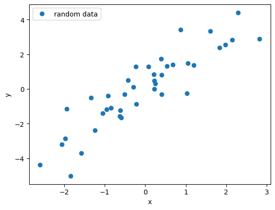

```python
plt.plot(x, y, 'o', label='random data')
plt.xlabel('x')
plt.ylabel('y')
plt.legend()
plt.show()
```

```python
from scipy.stats import linregress

slope, intercept, r_value, p_value, std_err = linregress(x, y)
```

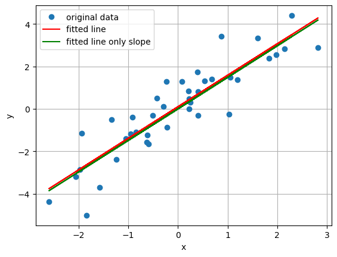

```python
plt.plot(x, y, 'o', label='original data')
plt.plot(x, intercept + slope*x, 'r', label='fitted line') #la droite rouge represente la regression lineaire on fait y = ax +b
plt.plot(x, slope*x, 'green', label='fitted line only slope')   # a = slope   ax =slope*x
plt.xlabel('x')                                                 # b = intercept = intercept est une constante
plt.ylabel('y')         #ax + b = y = fonction afffine = regression lineaire
plt.grid(True)          # ax permet de calculer la pente de la droite permet de savoir le taux de variation de y par rapport a x
plt.legend()
plt.show()
```

En plus de la pente et de l'ordonnée à l'origine du modèle ajusté, qui nous permettent de créer le tracé ci-dessus, la fonction `linregress()` renvoie également d'autres informations lorsqu'elle est appelée.

**Tâche 1 :**

- Imprimez la pente et l'ordonnée à l'origine, correspondent-elles à ce que vous pensez qu'elle devrait être en fonction du tracé et de l'équation utilisée pour générer les données ?
- Quel est le coefficient de corrélation de la régression linéaire ?

```python
#### Print slope and intercept

print(f'slope: {slope}, intercept: {intercept}')
```

```
slope: 1.4831232347196697, intercept: 0.09602333966709839
```

```python
### Correlation coefficient of the linear regression

print(f'correlation coefficient: {r_value}')

# c'est proche de 1 donc il y a une forte correlation entre x et y et la regression lineaire est bonne positif
# Prés de 89% de correlation entre x et y
```

```
correlation coefficient: 0.8970244827274227
```

- effectuer une régression linéaire pour les tableaux x2, y2 ci-dessous
- pente d'impression, ordonnée à l'origine, coefficient de corrélation
- créer un nuage de points des données et du modèle de régression ajusté

**Tâches 2**

```python
x2 = np.array([ 0.22827309,  1.0268903 , -0.83958485, -0.59118152, -0.9568883 ,
       -0.22232569, -0.61991511,  1.83790458, -2.05323076,  0.86858305,
       -0.92073444, -0.23231186,  2.1529569 , -1.33466147,  0.07637965,
       -1.24608928,  1.20227231, -1.04994158,  1.05661011, -0.41967767,
        2.29484234, -2.59448738,  2.8227564 ,  0.68088892, -1.57769345,
       -1.97625359,  0.53333982, -0.29086971, -0.51351967,  1.98262608,
        0.22600105, -1.83990496,  1.60767083,  0.38829194,  0.39973206,
        0.4054766 ,  0.21700177, -0.6334391 ,  0.24662153, -1.93954552])
```

```python
y2 = np.array([-0.18269538, -3.2202988 ,  1.33454079,  0.0630553 ,  1.6085824 ,
       -0.21392876,  0.58013809, -2.95481368,  2.772595  ,  0.88925045,
        2.29120304,  1.96443982, -3.42629745,  3.35625955,  1.07883913,
        1.24503731, -2.10728298,  1.65268524, -1.57941313,  1.73556883,
       -2.25436816,  3.15079347, -5.2922891 , -0.57261505,  0.89058007,
        2.88268935, -0.22134391,  0.95599233,  1.17298232, -3.20390167,
       -0.64017069,  0.32593461, -1.32103579,  0.6240868 , -0.35272815,
       -1.49437497,  0.20989395,  0.27261366, -0.40530206,  4.48897751])
```

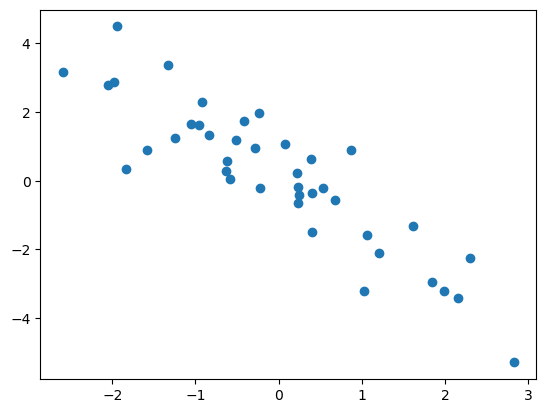

```python
plt.scatter(x2, y2)
plt.show()
```

Le but d'une regression linéaire c'est de faire la somme de la distance de tout les point soit la plus petit possible sur la régression linéaire (droite rechercher)

La corrélation valide l'impact d'une donnée sur l'autre

Permet d'estimer la tendance (en moyenne la courbe suit cette approximation)

```python
### your solution here
slope, intercept, r_value, p_value, std_err = linregress(x2, y2)
```

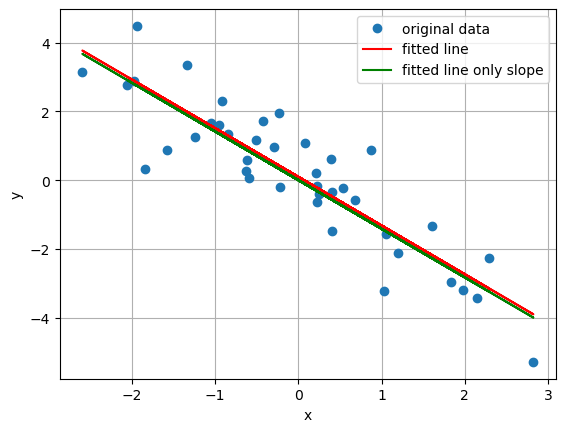

```python
plt.plot(x2, y2, 'o', label='original data')
plt.plot(x2, intercept + slope*x2, 'r', label='fitted line') # ax + b = y
plt.plot(x2, slope*x2, 'green', label='fitted line only slope') # ax c'est la pente = coeff
plt.xlabel('x')
plt.ylabel('y')
plt.grid(True)
plt.legend()
plt.show()
```

## Quatre ensembles de données différents : des résultats de régression différents ?

On peut être tenté de passer l’étape d’analyse exploratoire des données et d’appliquer directement un modèle de régression linéaire pour trouver des résultats rapides.

**Tâche 3 :**

Le fichier four_datasets.csv dans le dossier data contient quatre petits ensembles de données. Trouvez un modèle de régression linéaire pour chacun des quatre ensembles, **sans tracer les données au préalable**. Comparez les coefficients. Que concluez-vous sur cette base ?

```python
### Your solution here
data_1 = pd.read_csv('data/four_datasets.csv')
data_1.head()
```

|  | x1 | y1 | x2 | y2 | x3 | y3 | x4 | y4 |
| --- | --- | --- | --- | --- | --- | --- | --- | --- |
| 0 | 10 | 8.04 | 10 | 9.14 | 10 | 7.46 | 8 | 6.58 |
| 1 | 8 | 6.95 | 8 | 8.14 | 8 | 6.77 | 8 | 5.76 |
| 2 | 13 | 7.58 | 13 | 8.74 | 13 | 12.74 | 8 | 7.71 |
| 3 | 9 | 8.81 | 9 | 8.77 | 9 | 7.11 | 8 | 8.84 |
| 4 | 11 | 8.33 | 11 | 9.26 | 11 | 7.81 | 8 | 8.47 |

- Créez maintenant un tracé de chaque ensemble de données, y compris la ligne de régression linéaire

```python
### Your solution here

slope, intercept, r_value, p_value, std_err = linregress(data_1['x1'], data_1['y1'])
```

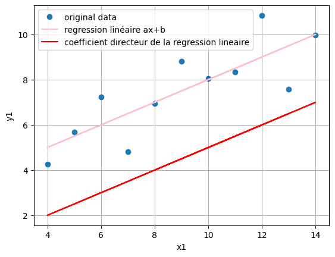

```python
plt.plot(data_1['x1'], data_1['y1'], 'o', label='original data')
plt.plot(data_1['x1'], intercept + slope*data_1['x1'], 'pink', label= 'regression linéaire ax+b')
plt.plot(data_1['x1'], slope*data_1['x1'], 'r', label='coefficient directeur de la regression lineaire')
plt.xlabel('x1')
plt.ylabel('y1')
plt.grid(True)
plt.legend()
plt.show()
```

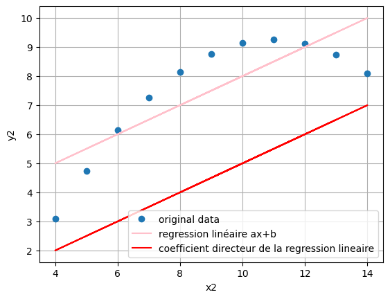

```python
plt.plot(data_1['x2'], data_1['y2'], 'o', label='original data')
plt.plot(data_1['x2'], intercept + slope*data_1['x2'], 'pink', label= 'regression linéaire ax+b')
plt.plot(data_1['x2'], slope*data_1['x2'], 'r', label='coefficient directeur de la regression lineaire')
plt.xlabel('x2')
plt.ylabel('y2')
plt.grid(True)
plt.legend()
plt.show()
```

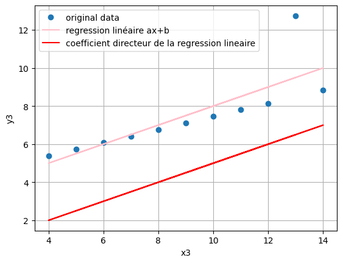

```python
plt.plot(data_1['x3'], data_1['y3'], 'o', label='original data')
plt.plot(data_1['x3'], intercept + slope*data_1['x3'], 'pink', label= 'regression linéaire ax+b')
plt.plot(data_1['x3'], slope*data_1['x3'], 'r', label='coefficient directeur de la regression lineaire')
plt.xlabel('x3')
plt.ylabel('y3')
plt.grid(True)
plt.legend()
plt.show()
```

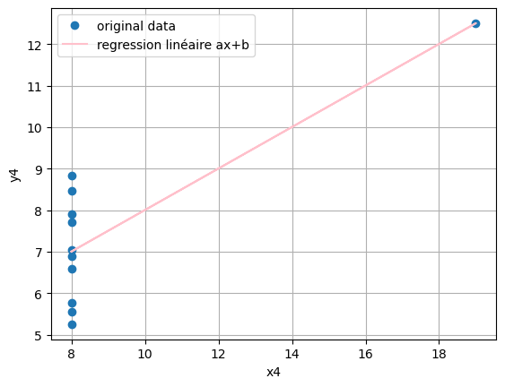

```python
plt.plot(data_1['x4'], data_1['y4'], 'o', label='original data')
plt.plot(data_1['x4'], intercept + slope*data_1['x4'], 'pink', label= 'regression linéaire ax+b')
#plt.plot(data_1['x4'], slope*data_1['x4'], 'r', label='coefficient directeur de la regression lineaire')
plt.xlabel('x4')
plt.ylabel('y4')
plt.grid(True)
plt.legend()
plt.show()
```

```python
print(f'correlation coefficient: {r_value}')
```

```
correlation coefficient: 0.8164205163448399
```

Conclusion :

Le fait que la corrélation linéaire soit proche de 1 donc valider ne démontre pas la forme de la courbe cf data_1 (x2, y2 et x4, y4) et la regression linéaire ne suit pas forcément la courbe et ne donne pas forcément la forme courbe

## Package de modèles de statistiques

```python
np.random.seed(25)
x = np.random.normal(size = 40)
y = 1.6*x + np.random.normal(size = 40)
```

```python
import statsmodels.api as sm

x = sm.add_constant(x) # an intercept term to the model
model = sm.OLS(y, x)
results = model.fit()

print(results.summary())
```

```
                            OLS Regression Results
==============================================================================
Dep. Variable:                      y   R-squared:                       0.805
Model:                            OLS   Adj. R-squared:                  0.800
Method:                 Least Squares   F-statistic:                     156.5
Date:                Sat, 25 Oct 2025   Prob (F-statistic):           4.78e-15
Time:                        03:39:32   Log-Likelihood:                -54.427
No. Observations:                  40   AIC:                             112.9
Df Residuals:                      38   BIC:                             116.2
Df Model:                           1
Covariance Type:            nonrobust
==============================================================================
                 coef    std err          t      P>|t|      [0.025      0.975]
------------------------------------------------------------------------------
const          0.0960      0.153      0.627      0.534      -0.214       0.406
x1             1.4831      0.119     12.511      0.000       1.243       1.723
==============================================================================
Omnibus:                        0.272   Durbin-Watson:                   1.805
Prob(Omnibus):                  0.873   Jarque-Bera (JB):                0.093
Skew:                          -0.116   Prob(JB):                        0.955
Kurtosis:                       2.958   Cond. No.                         1.29
==============================================================================

Notes:
[1] Standard Errors assume that the covariance matrix of the errors is correctly specified.
```

```python
results.params
```

```
array([0.09602334, 1.48312323])
```

### Tâche 3 :

Pour vous aider à comprendre le résultat, notez la signification des termes rapportés :

- *R au carré :* La formule la plus courante pour calculer le R au carré est la suivante : R2=1-RSS/TSS, où RSS est la somme des carrés résiduels et TSS la somme totale des carrés.

https://www.datacamp.com/fr/tutorial/r-squared

- *coef (coefficient de régression)* Le coefficient de régression indique dans quelle mesure la valeur d'une variable dépendante varie avec la variation de la valeur de la variable indépendante (aussi appelée variable explicative).

https://www.datacamp.com/fr/tutorial/linear-regression-in-python (formule) https://moncoachdata.com/blog/regression-lineaire-avec-python/

- *erreur standard (erreur standard)* Pour calculer l'erreur standard de la moyenne (SEM) en Python, utilisez la fonction **sem()** de la bibliothèque scipy .

Règle d'erreur standard unique : Cette règle permet de comparer des modèles comportant différents nombres de paramètres afin de sélectionner le modèle le plus parcimonieux et présentant le moins d'erreurs . Pour l'utiliser, il faut trouver le modèle présentant le minimum d'erreurs, puis sélectionner le modèle le plus simple dont la moyenne se situe à moins d'un écart type du minimum

[figure not shown]

- *P>|t| (valeur p)* La P-Value est la mesure de probabilité selon laquelle une différence observée pourrait s'être produite par simple hasard. Plus la p-value est faible, plus la différence observée est statistiquement significative. Les P-Values fournissent une alternative aux niveaux de confiance prédéfinis pour les tests d'hypothèse, offrant un moyen de comparer les résultats de différents tests.

https://docs.kanaries.net/fr/topics/Python/t-test-and-p-value-in-python

- *[0,025 0,975] (intervalles de confiance)* Un intervalle de confiance pour une moyenne est une plage de valeurs susceptible de contenir une moyenne de population avec un certain niveau de confiance.

https://statorials.org/intervalles-de-confiance-python/

exos à faire en suppléments https://campus.datacamp.com/fr/courses/hypothesis-testing-in-python/hypothesis-testing-fundamentals?ex=11

**Notez ce qu'est la régression des *moindres carrés*.** : Cette méthode des moindres carrés consiste à rendre minimale la distance du nuage de points à une droite d'équation y = a x + b , c'est-à-dire minimiser la quantité : q ( a , b ) = ∑ i = 1 n e i 2 = ∑ i = 1 n ( y i − ( a x i + b ) ) 2 .

https://www.f-legrand.fr/scidoc/docmml/numerique/optimisation/moindrecarre/moindrecarre.html https://gvallverdu.gitbooks.io/python_sciences/content/moindres_carres.html

REMARQUE : les chapitres d'introduction de l'ISLR expliquent la plupart d'entre eux. Sinon, recherchez-les en ligne.

# Exercice 2 Rechercher des associations aux urgences

## Tâches 1

Vous devez :

1. - charger les données

```python
def load_dtoc_dataset():
    '''
    Charge les ensembles de données long_wait et dtoc en mémoire
    Renvoie un tuple de numpy.ndarrays représentant
    violation et ensemble de données dtoc respectivement.
    '''
    #notez que nous utilisons skip_header car l'ensemble de données a des descripteurs de colonnes
    dtocs = np.genfromtxt('./data/dtocs.csv', skip_header=1)
    long_waits = np.genfromtxt('./data/long_waits.csv', skip_header=1)
    return long_waits, dtocs


long_waits, dtocs = load_dtoc_dataset()  # sépare les deux csv
```

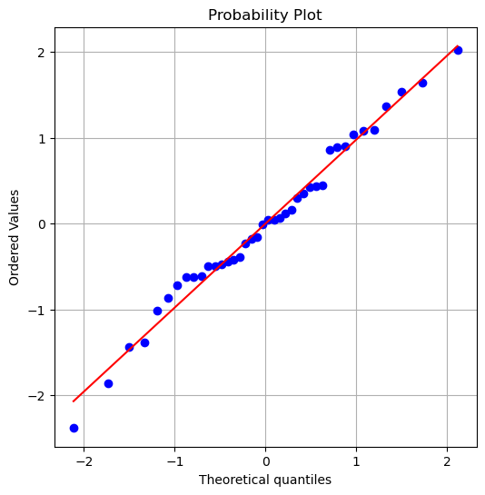

```python
from scipy.stats import probplot
fig, ax = plt.subplots(figsize=(6,6))
probplot(results.resid, plot=ax, fit=True) # l'attribut .resid contient un tableau numpy des résidus
plt.grid(True)
```

```python
load_dtoc_dataset() #charge les deux csv
```

```
(array([ 33184.     ,  41151.     ,  47414.     ,  46436.42857,
         89917.28571,  72889.28571,  46942.85714,  59172.71429,
         57379.85714,  54805.42857,  51701.71429,  44885.42857,
         45076.57143,  55392.42857,  62452.71429,  59131.85714,
         72832.     ,  73746.57143,  85427.14286,  66947.     ,
         64561.     ,  61520.71429,  61439.28571,  56433.57143,
         54607.     ,  59110.14286,  68868.42857,  70014.28571,
         97186.57143,  94561.42857,  94112.28571, 120995.     ,
        120121.7143 ,  64823.28571,  56340.     ,  65588.71429,
         68396.14286,  74543.71429,  79250.     ,  70781.14286,
         84049.28571,  83995.71429,  89101.28571,  85828.71429,
         88957.14286, 102189.7143 ,  92863.71429,  96272.     ,
         88879.71429,  99849.71429, 118978.1429 , 119731.1429 ,
        192155.     , 153156.4286 , 132867.8571 , 141194.     ,
        125799.2857 , 110284.4286 ,  99324.     ,  97475.     ,
        106475.     , 123111.     , 147554.     , 163472.     ,
        168604.     , 216286.     , 229081.     , 265834.     ,
        186122.     , 201329.     , 184912.     , 201973.     ,
        174419.     , 182597.     , 219137.     , 221713.     ,
        268818.     , 281612.     , 216416.     , 201392.     ]),
 array([4940., 5004., 4588., 4409., 3861., 4597., 4404., 4170., 3910.,
        4056., 4137., 4228., 4144., 4165., 4150., 4165., 3617., 4094.,
        4007., 4028., 3954., 3857., 4086., 4031., 3961., 4102., 4115.,
        3894., 3448., 4188., 4007., 4053., 4046., 4184., 3888., 3961.,
        4084., 4231., 4147., 4200., 3649., 4221., 4276., 4327., 4207.,
        4516., 4363., 4612., 4704., 4960., 4930., 5063., 4475., 5221.,
        4942., 4948., 4739., 4972., 4996., 4888., 5114., 5247., 5330.,
        5573., 5004., 5777., 5714., 5601., 5852., 5996., 6152., 6361.,
        6387., 6759., 6777., 6771., 6167., 7118., 6855., 6648.]))
```

**Le fichier csv : longswaits** corresponds aux longs délais d'attente aux urgences (plus de 4 heures) est également enregistré.

```python
long_waits # charge seulement un seul csv le long_waits
```

```
array([ 33184.     ,  41151.     ,  47414.     ,  46436.42857,
        89917.28571,  72889.28571,  46942.85714,  59172.71429,
        57379.85714,  54805.42857,  51701.71429,  44885.42857,
        45076.57143,  55392.42857,  62452.71429,  59131.85714,
        72832.     ,  73746.57143,  85427.14286,  66947.     ,
        64561.     ,  61520.71429,  61439.28571,  56433.57143,
        54607.     ,  59110.14286,  68868.42857,  70014.28571,
        97186.57143,  94561.42857,  94112.28571, 120995.     ,
       120121.7143 ,  64823.28571,  56340.     ,  65588.71429,
        68396.14286,  74543.71429,  79250.     ,  70781.14286,
        84049.28571,  83995.71429,  89101.28571,  85828.71429,
        88957.14286, 102189.7143 ,  92863.71429,  96272.     ,
        88879.71429,  99849.71429, 118978.1429 , 119731.1429 ,
       192155.     , 153156.4286 , 132867.8571 , 141194.     ,
       125799.2857 , 110284.4286 ,  99324.     ,  97475.     ,
       106475.     , 123111.     , 147554.     , 163472.     ,
       168604.     , 216286.     , 229081.     , 265834.     ,
       186122.     , 201329.     , 184912.     , 201973.     ,
       174419.     , 182597.     , 219137.     , 221713.     ,
       268818.     , 281612.     , 216416.     , 201392.     ])
```

2. - tracer les 2 séries chronologiques avec 2 courbes

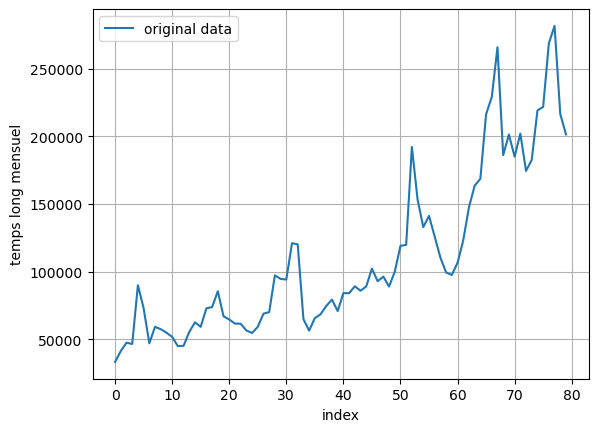

```python
plt.plot(long_waits, '-', label='original data')
plt.xlabel('index')
plt.ylabel('temps long mensuel')
plt.grid(True)
plt.legend()
plt.show()
```

**Le fichier csv : dtocs** "les patients qui sont médicalement aptes à rentrer chez eux mais qui sont toujours hospitalisés sont appelés « transferts de soins retardés »

```python
dtocs # charge csv dtocs
```

```
array([4940., 5004., 4588., 4409., 3861., 4597., 4404., 4170., 3910.,
       4056., 4137., 4228., 4144., 4165., 4150., 4165., 3617., 4094.,
       4007., 4028., 3954., 3857., 4086., 4031., 3961., 4102., 4115.,
       3894., 3448., 4188., 4007., 4053., 4046., 4184., 3888., 3961.,
       4084., 4231., 4147., 4200., 3649., 4221., 4276., 4327., 4207.,
       4516., 4363., 4612., 4704., 4960., 4930., 5063., 4475., 5221.,
       4942., 4948., 4739., 4972., 4996., 4888., 5114., 5247., 5330.,
       5573., 5004., 5777., 5714., 5601., 5852., 5996., 6152., 6361.,
       6387., 6759., 6777., 6771., 6167., 7118., 6855., 6648.])
```

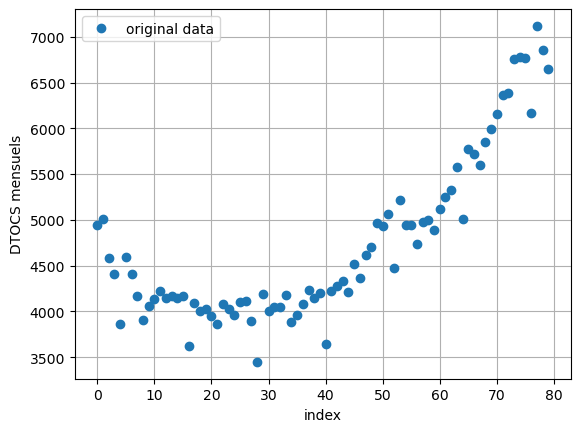

```python
plt.plot(dtocs, 'o', label='original data')
plt.xlabel('index')
plt.ylabel('DTOCS mensuels')
plt.grid(True)
plt.legend()
plt.show()
```

3. - tracer ensuite les données sous forme de nuage de points (Y : dtocs, X : long_waits)
4. - ajoutez votre ligne de régression au nuage de points

```python
#Tracer une regression liéaire entre le csv dtocs et long_waits

x = dtocs
y = long_waits

slope, intercept, r_value, p_value, std_err = linregress(x, y)
```